# Homework 1

Casey Gibson

### Problem 1

$$p(\theta) = \frac{1}{21} \text{ for } \theta=0,0.05,0.1,...,1$$
$$Y | \theta \sim Binom(n,\theta)$$

$$P(Y = 5 | \theta =.05) = \binom{n}{5}\theta^5(1-\theta)^{n-5} = \binom{100}{5}.05^5(1-.05)^{100-5} \approx .180$$

$$P(Y = 5 | \theta =.5) = \binom{n}{5}\theta^5(1-\theta)^{n-5} = \binom{100}{5}.5^5(1-.5)^{100-5} \approx 5.94 \text{ x } 10^{-23}$$
$$P(\theta =.05 | Y = 5) = \frac{P(Y=5|\theta =.05 ) P(\theta=.05)}{P(Y=5)}$$
If we denote $\Theta = \{0,1,2..,20\}$ then $\theta \in \frac{\Theta}{20}$

$$P(Y = 5) = \sum_{\theta' \in \Theta} P(Y,\theta') = \sum_{\theta' \in \Theta} P(Y |\theta')P(\theta') = \sum_{i=0}^{20} P(Y = 5 | \theta' = \frac{i}{20})P(\theta'=\frac{i}{20})$$

$$=\sum_{i=0}^{20} \binom{100}{5}(\frac{i}{20})^5(1-(\frac{i}{20}))^{100-5}\frac{1}{21} \approx .0102$$

$$P(\theta =.05 | Y = 5) = \frac{ .1800178* \frac{1}{21}}{.0102393} \approx .837$$

$$P(\theta =.5 | Y = 5) = \frac{ 5.93914e^{-23} \frac{1}{21}}{.0102393} \approx 2.76 \ x \ 10^{-22}$$

### Problem 2

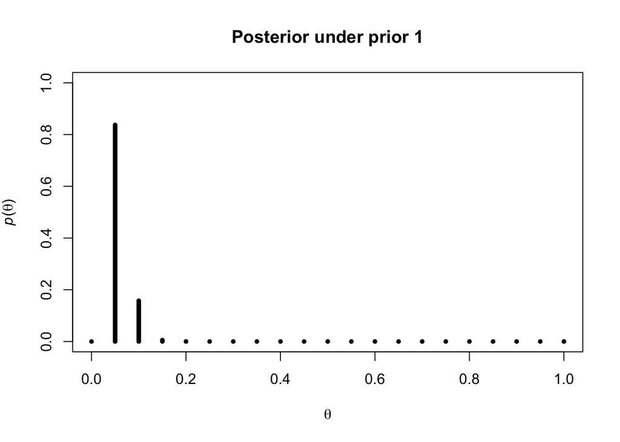

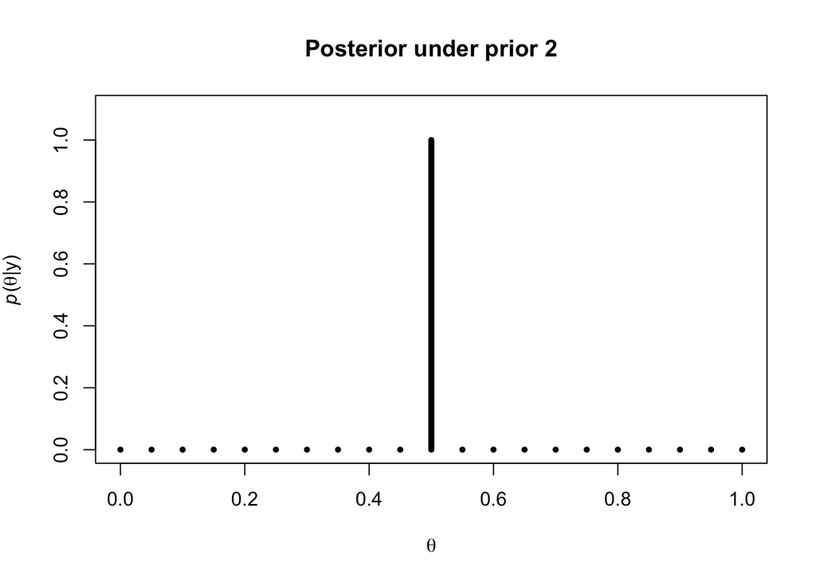

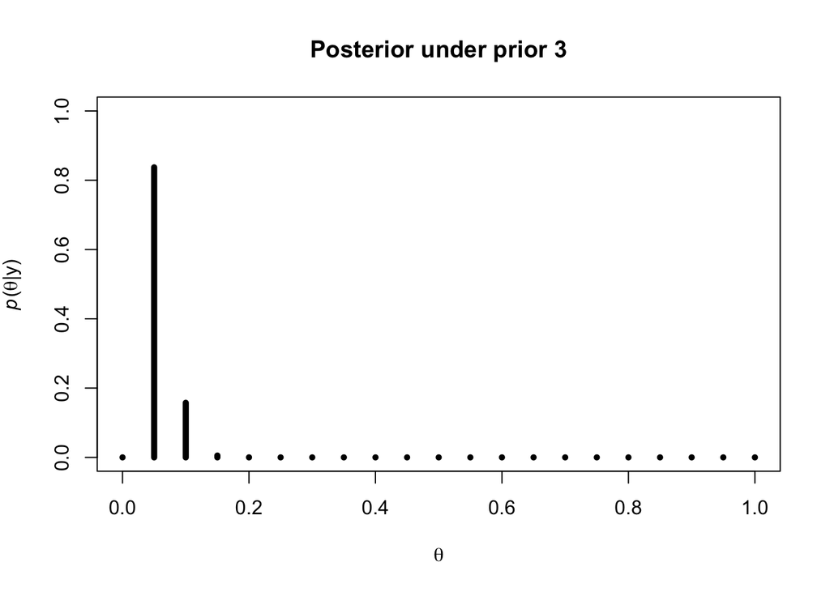

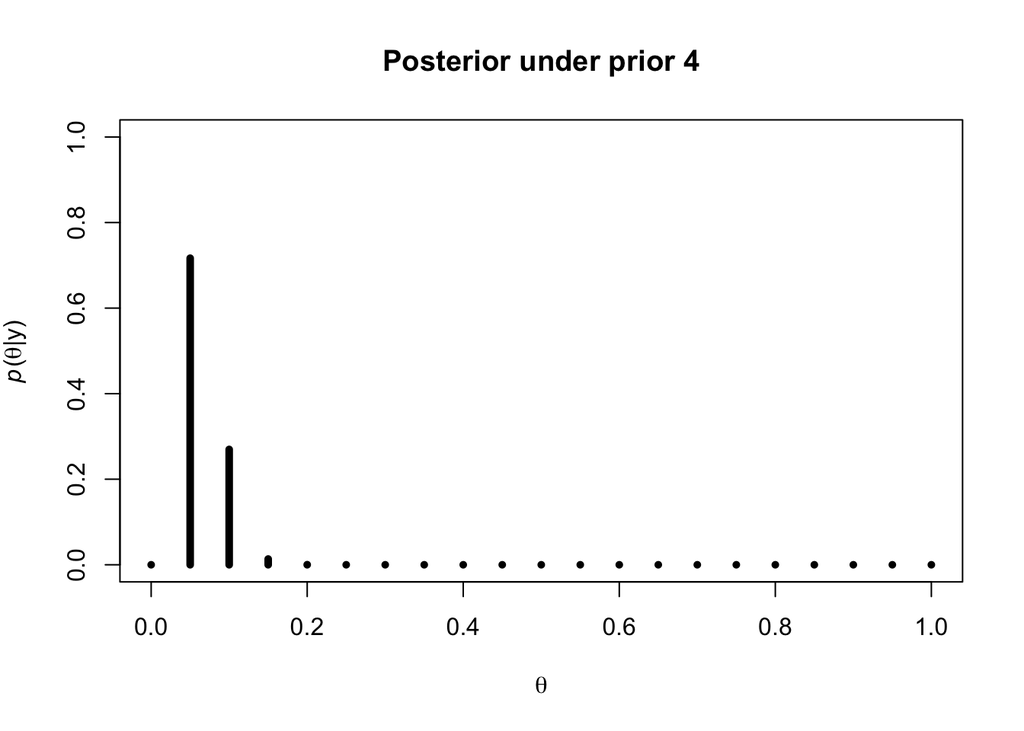

| Expected Value Prior 1 | Expected Value Prior 2 | Expected Value Prior 3 | Expected Value Prior 4 |
| --- | --- | --- | --- |
| 0.0584 | 0.5 | 0.0584 | 0.0649 |

#### Results

Prior $2$ clearly pulls the posterior towards the right because it forces all $\theta's$ less than $.5$ to have $0$ probability. Prior $3$ yeilds essentially the same results as prior $1$, which makes sense because the likelihood is so skewed towards the range $0,.5$, so excluding $.5,1$ does not change the posterior much. Prior $4$ pushes the posterior slightly upwards, which again makes sense because the prior assigns higher probabilities to higher values of theta, pushing the posterior to the right.

### Problem 3

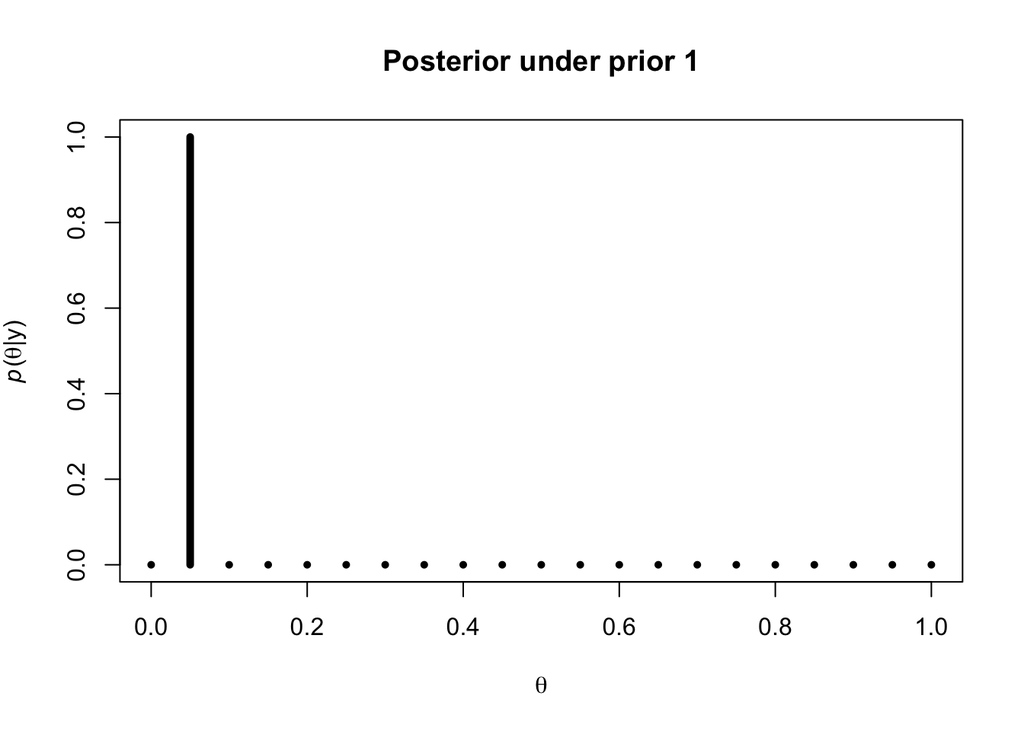

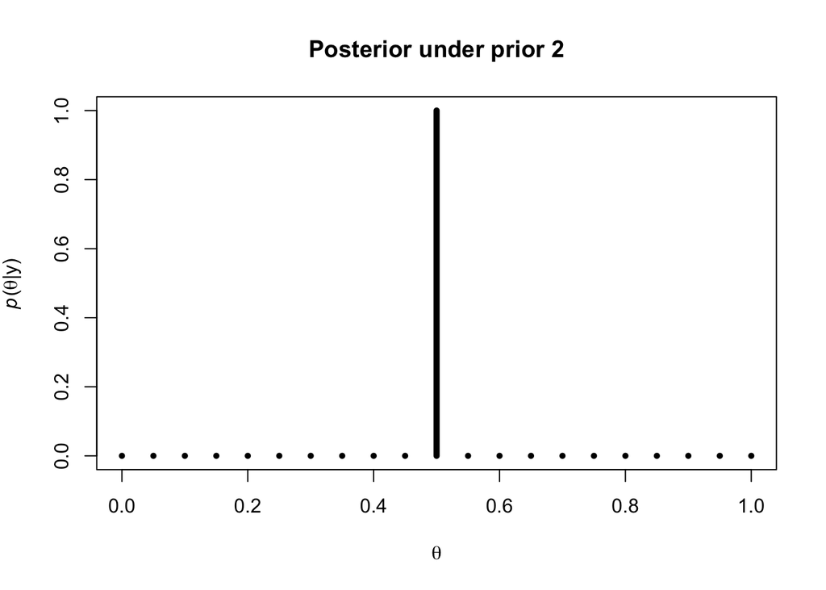

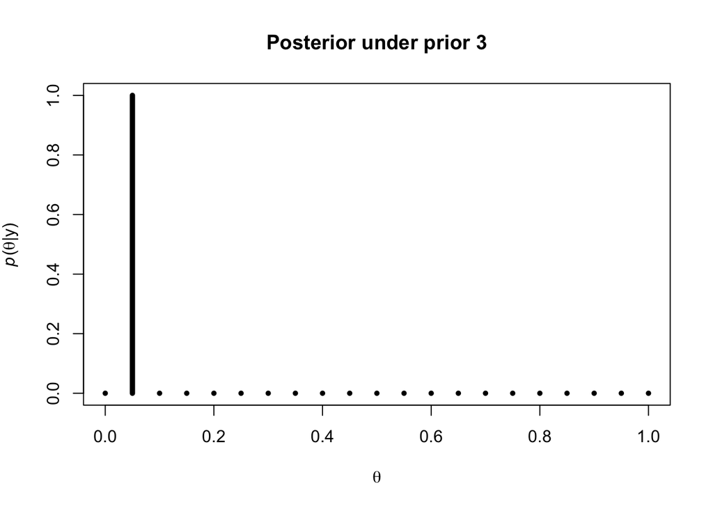

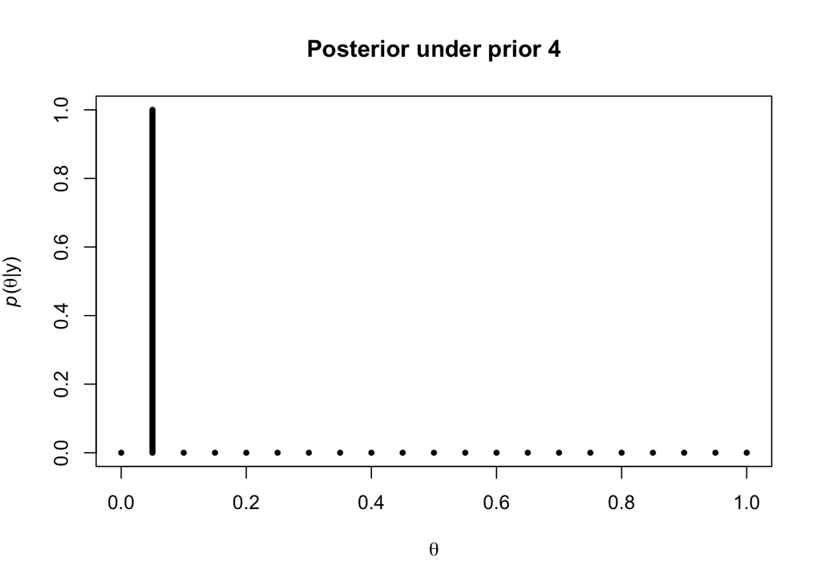

| Expected Value Prior 1 | Expected Value Prior 2 | Expected Value Prior 3 | Expected Value Prior 4 |
| --- | --- | --- | --- |
| 0.05 | 0.5 | 0.05 | 0.05 |

#### Results

As we get more data the effect of the prior diminishes (which is called “swamping” I think?). This makes more sense, to me at least, if we consider the log posterior.

$$p(\theta |y ) \propto p(y | \theta)p(\theta)$$

taking logs we see

$$log \ p(\theta|y) \propto log \ p(y | \theta) + log \ p(\theta)$$

$$log / p(\theta|y) \propto log \ \prod_{i=1}^nL(\theta | y) + log \ p(\theta)$$
where $L(\theta | y)$ is the likelihood function.

This becomes
$$log \ p(\theta|y) \propto \sum_{i=1}^n log \ L(\theta | y) + log \ p(\theta)$$
Now we can clearly see, as $n$ increases the effect of the $log \ p(\theta)$ dimishes since the sum term contributes more than the prior. It is harder for me to see this clearly in the non-log space because we are dealing with multiplication of small numbers.